# Algorithm 1 of van de Geer and Stucky (2016)

Aaron J. Molstad

## Computing time comparisons

First, we will generate a small dataset on which we will apply our algorithm, CVX, and the procedure proposed by van de Geer and Stucky (2016) using code provided in personal communcation with the authors.

```r
set.seed(1)
p = 100
n = 200
q = 20

# -------------------------------- Generate predictors
# --------------------------------
SigmaX <- matrix(0, nrow = p, ncol = p)
for (j in 1:p) {
    for (k in 1:p) {
        SigmaX[j, k] <- 0.7^abs(j - k)
    }
}
diag(SigmaX) <- 1
eo <- eigen(SigmaX)
SigmaXsqrt <- eo$vec %*% diag(eo$val^0.5) %*% t(eo$vec)
X <- matrix(rnorm(n * p), nrow = n) %*% SigmaXsqrt
# ----------------------------------- Generate regression coefficients
# -----------------------------------
beta <- matrix(0, nrow = p, ncol = q)
beta[sample(1:(p * q), floor(p * q) * 0.04, replace = TRUE)] <- 1

# ------------------------------------- Generate responses
# -------------------------------------
Sigma <- matrix(0, nrow = q, ncol = q)
for (k in 1:q) {
    for (j in 1:q) {
        Sigma[j, k] <- 0.9^abs(j - k)
    }
}
diag(Sigma) <- 1
eo <- eigen(Sigma)
Sigmasqrt <- eo$vec %*% diag(eo$val^0.5) %*% t(eo$vec)
Y = X %*% beta + matrix(rnorm(n * q), nrow = n) %*% Sigmasqrt
```

Then, using our R package, we select a tuning parameter by cross-validation.

```r
source("~/Documents/GitHub/MultivarSqrtLasso/VGS/MSRL_Functions.R")
library(Matrix)
mod1 <- MSRL.cv(X = X, Y = Y, nlambda = 50, standardize = FALSE, ADMM = FALSE,
                nfolds = 5,  weighted = FALSE, delta = .5, tol = 1e-10, quiet = TRUE,
                inner.quiet=TRUE)
lambda.best <- mod1$lam.min
```

Using the tuning parameter selected by cross-validation, we now obtain the MSRL estimator at this tuning parameter value. To compare the various algorithms, we compute the estimator using our package, $\texttt{CVXR}$, and the algorithm of van de Geer and Stucky (2016).

```r
X1 <- X - rep(1, dim(X)[1])%*%t(colMeans(X))
Y1 <- Y - rep(1, dim(Y)[1])%*%t(colMeans(Y))
eval.Obj <- function(X, Y, beta.iter, lambda){
  n <- dim(Y)[1]
  temp <- svd(Y - X%*%beta.iter)
  out <- (1/sqrt(n))*sum(temp$d) + lambda*sum(abs(beta.iter))
  return(out)
}

#lambda.test <- lambda.test/100
ptm <- proc.time()
mod1 <- MSRL.cv(X = X, Y = Y, lambda.vec = lambda.best, standardize = FALSE, ADMM = FALSE,
                nfolds = NULL, weighted = FALSE, delta = .1, tol = 1e-10, quiet = TRUE, beta.init = matrix(0, nrow=p, ncol=q),
                inner.quiet=TRUE)
proc.time() - ptm
```

```
##    user  system elapsed
##   0.284   0.014   0.298
```

```r
(min.Obj <- eval.Obj(X1, Y1, matrix(mod1$beta, nrow=p, ncol=q), lambda.best))
```

```
## [1] 36.11789
```

Next, we solve this problem using $\texttt{CVXR}$, which is significantly slower and less accurate than our algorithm, but is a reliable off the shelf solver for this problem.

```r
library(CVXR)
beta.cvx <- Variable(p,q)
obj <- (1/sqrt(n))*cvxr_norm(Y1 - X1%*%beta.cvx, "nuc") + lambda.best*p_norm(beta.cvx,1)
prob <- Problem(Minimize(obj))
ptm <- proc.time()
result <- solve(prob)
proc.time() - ptm
```

```
##    user  system elapsed
## 229.339   3.111 232.706
```

```r
CVX.obj <- eval.Obj(X1, Y1, matrix(result[[3]], nrow=p, ncol=q), lambda.best)

# -----------------------------
# Compare estimates
# -----------------------------
(matrix(result[[3]], nrow=p, ncol=q) - matrix(mod1$beta, nrow=p, ncol=q))[1:5, 1:5]
```

```
##               [,1]          [,2]          [,3]          [,4]         [,5]
## [1,]  1.455340e-05 -9.027015e-07  2.985118e-07  5.940808e-07 1.291346e-06
## [2,] -8.246145e-07 -1.778373e-06 -9.765754e-08 -2.248107e-07 2.778549e-07
## [3,] -1.693689e-07 -1.434604e-06 -5.475475e-07 -5.696249e-07 2.486799e-06
## [4,] -1.424141e-06 -1.647590e-06 -5.951012e-07 -1.302604e-06 2.123572e-06
## [5,] -8.748195e-07 -1.391326e-06 -1.495425e-06 -1.630481e-06 7.817708e-06
```

```r
# --------------------------------
# Compare objective function values
# -------------------------------
cat("CVX: Objective function value = ", CVX.obj, "\n")
```

```
## CVX: Objective function value =  36.11848
```

```r
cat("MSRL: Objective function value = ", min.Obj, "\n")
```

```
## MSRL: Objective function value =  36.11789
```

Finally, we now try to compute the estimator using the Algorithm 1 of van de Geer and Stucky (2016). First, we load the authors’ implementation below, which we have modified to track the objective function value across iterations. We try two values of $K$ after initializing at zeros matrix – the default and a slightly larger value.

```r
VGS_Opt_Default <- msrL(Y = Y1, X = X1, b0 = matrix(0, nrow=p,  ncol=q), l = lambda.best/(sqrt(sum(X1^2))/sqrt(2)), K = (sqrt(sum(X1^2))/sqrt(2)), s = 1e-8, quiet = TRUE)
```

```
## has converged with accuracy: 1e-08    Number of iterations:2939
```

Now we plot the objective function values across iterations

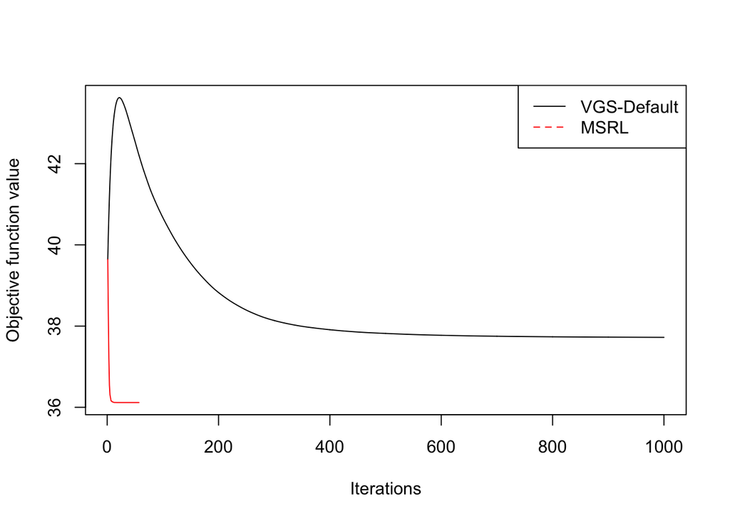

```r
VGS_Opt_Default$objFunc <- VGS_Opt_Default$objFunc[-c(length(VGS_Opt_Default$objFunc)-1, length(VGS_Opt_Default$objFunc))]
plot(VGS_Opt_Default$objFunc[1:1000], xlab="Iterations", ylab="Objective function value",
     ylim=c(min(min.Obj, min(VGS_Opt_Default$objFunc)), max(VGS_Opt_Default$objFunc)), type="l")
lines(mod1$objOut[1:max(which(mod1$objOut!=0))], lty=1, col="red")
legend("topright", legend=c("VGS-Default", "MSRL"), col = c("black",  "red"), lty=c(1, 2))
```

It is evident that the objective function value converged using the algorithm of van de Geer and Stucky (2016), but it converged to a value of $\beta$ which does not (approximately) minimize the multivariate-square root lasso criterion. Next, we check the first order optimality conditions for each of the solutions we have obtained. First, we check using the solution obtained using our esimator. Note at the exact solution, $t_1$ and $t_2$ would both equal zero.

```r
svdtemp <- svd(Y1 - X1%*%matrix(mod1$beta, nrow=p, ncol=q))
keep <- (1/sqrt(n))*crossprod(X1, tcrossprod(svdtemp$u, svdtemp$v))
t1 <- sum((abs(keep) > lambda.best)[which(matrix(mod1$beta, nrow=p, ncol=q) == 0)])/sum(matrix(mod1$beta, nrow=p, ncol=q) == 0)

if(any(matrix(mod1$beta, nrow=p, ncol=q)!=0)){
        t2 <- max(abs(keep - lambda.best*sign(matrix(mod1$beta, nrow=p, ncol=q)))[which(matrix(mod1$beta, nrow=p, ncol=q) != 0)])
} else {
        t2 <- 0
}

cat("First order optimality via prox-linear ADMM:  t1 = ", t1, ", t2 = ", t2, "\n")
```

```
## First order optimality via prox-linear ADMM:  t1 =  0 , t2 =  2.596562e-07
```

We see that both $t_1$ and $t_2$ are very close to zero using our algorithm. Hence, we have a relatively accurate solution

Then, we check the first order conditions at the solution obtained by the algorithm of Van de Geer and Stucky.

```r
svdtemp <- svd(Y1 - X1%*%matrix(VGS_Opt_Default$b, nrow=p, ncol=q))
keep <- (1/sqrt(n))*crossprod(X1, tcrossprod(svdtemp$u, svdtemp$v))
t1 <- sum((abs(keep) > lambda.best)[which(matrix(mod1$beta, nrow=p, ncol=q) == 0)])/sum(matrix(mod1$beta, nrow=p, ncol=q) == 0)
if(any(matrix(mod1$beta, nrow=p, ncol=q)!=0)){
        t2 <- max(abs(keep - lambda.best*sign(matrix(mod1$beta, nrow=p, ncol=q)))[which(matrix(mod1$beta, nrow=p, ncol=q) != 0)])
} else {
        t2 <- 0
}
cat("First order optimality via Algorithm of VGS: t1 = ", t1, ", t2 = ", t2, "\n")
```

```
## First order optimality via Algorithm of VGS: t1 =  0 , t2 =  0.2594667
```

Let $\hat{U}\hat{D}\hat{V}' = Y - X\hat{\beta}$ be the singular value decomposition of the residuals at the solution $\hat{\beta}$. Note that
$$t_2 = \max_{j,k: \hat{\beta}_{j,k}!=0} |[\frac{1}{\sqrt{n}}X'\hat{U}\hat{V}' - \lambda{\rm sign}(\hat{\beta})]_{j,k}|.$$
Above, we see that this value based on the solution obtained by the algorithm of van de Geer and Stucky is remarkably large, indicating a very inaccurate solution.

## Alternative $K$ values for algorithm of van de Geer and Stucky (2016)

We now try alternative step-size parameter values in the algorithm of Van de Geer and Stucky.

```r
VGS_Opt_K2 <- msrL(Y = Y1, X = X1, b0 = matrix(0, nrow=p,  ncol=q), l = lambda.best/(sqrt(sum(X1^2))/sqrt(2)), K = 2*(sqrt(sum(X1^2))/sqrt(2)), s = 1e-8, quiet = TRUE)
```

```
## has converged with accuracy: 1e-08    Number of iterations:8585
```

```r
VGS_Opt_K5 <- msrL(Y = Y1, X = X1, b0 = matrix(0, nrow=p,  ncol=q), l = lambda.best/(sqrt(sum(X1^2))/sqrt(2)), K = 5*(sqrt(sum(X1^2))/sqrt(2)), s = 1e-8, quiet = TRUE)
```

```
## has NOT converged in 10000 iterations, with accuracy:1e-08
```

```r
VGS_Opt_K2$objFunc <- VGS_Opt_K2$objFunc[-c(length(VGS_Opt_K2$objFunc)-1, length(VGS_Opt_K2$objFunc))]

VGS_Opt_K5$objFunc<- VGS_Opt_K5$objFunc[-c(length(VGS_Opt_K5$objFunc)-1, length(VGS_Opt_K5$objFunc))]
```

Note that making $K$ larger does not appear to fix the issue as the objective function values get much larger than that obtained by the default implementation:

```r
cat(VGS_Opt_K2$objFunc[length(VGS_Opt_K2$objFunc)], "\n")
```

```
## 56.22011
```

```r
cat(VGS_Opt_K5$objFunc[length(VGS_Opt_K5$objFunc)], "\n")
```

```
## 72.86657
```